# Create Quantiles/Deciles Plot

This notebook will create a quantiles plot.

The aim of this plot is to ‘see’ how quickly adjuvant abemaciclib is adopted. Abemaciclib is the only CDK4/6 inhibitor that is used in the adjuvant setting and was funded through the Cancer Drugs Fund on 17th June 2022. We can therefore assume all use prior to June was not adjuvant, and as the use was fairly steady see the change in use from June as *likely* to be adjuvant use.

The three key dates are 17th June (CDF Funding), 20 July 2022 (NICE formal approval), and 90 days later - when implementation of NICE guidance is mandated.

## Load the data

```r
# load some required packages for data carpentry and visualisation
require(dplyr)
require(tidyr)
require(ggplot2)

BMJ_colours <- c("Palbociclib"="#1f5189", "Abemaciclib"="#c50084","Ribociclib"="#00b2a9", "Palbociclib_line" = "#2a6ebb", "Abemaciclib_line"="#ff83d6","Ribociclib_line"="#70fff8", "High_line"= "#5e3baa", "Low_line" = "#CD202C")

# Get the dataset
# Requires cleaned data
cdk46Data <- readRDS(here::here("data/cdk46_op_hosp_clean.RDS"))

# agregate the data to VTM & month & trust
cdk46Data |>
  # exclude dates in 2025
  filter(year_month < as.Date("2025-01-01")) |>
  # summarise the data using month and organisation
  group_by(year_month, vtm_name, new_code ) |>
  # As not comparing across drugs - can simply use quantity rather than dose
  summarise(qty=sum(ddd_quantity)) -> trustData

trustData |>
  pivot_wider(id_cols = c(year_month, new_code), values_from = qty, names_from = vtm_name) |>
  ungroup()|>
  rowwise() |>
  mutate(total = sum(Palbociclib, Abemaciclib, Ribociclib, na.rm = T)) |>
  mutate(pct_abema = Abemaciclib/total) -> trustData

head(trustData)
```

| year_month | new_code | Palbociclib | Ribociclib | Abemaciclib | total | pct_abema |
| --- | --- | --- | --- | --- | --- | --- |
| 2019-01-01 | R1F | 173.1383 | 18.66667 | NA | 191.8050 | NA |
| 2019-01-01 | R1H | 1144.9468 | NA | NA | 1144.9468 | NA |
| 2019-01-01 | R1K | 312.7660 | NA | NA | 312.7660 | NA |
| 2019-01-01 | RA2 | 1329.2553 | 100.00000 | NA | 1429.2553 | NA |
| 2019-01-01 | RA4 | 340.6915 | NA | NA | 340.6915 | NA |
| 2019-01-01 | RA7 | 1167.2872 | NA | NA | 1167.2872 | NA |

## Plot the median use monthly

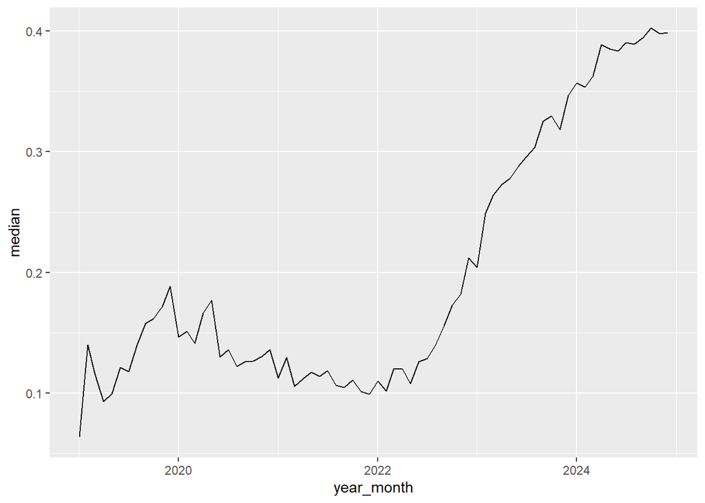

```r
trustData |>
  group_by(year_month) |>
  summarise(median = median(pct_abema, na.rm = T)) |>
  ggplot(aes(x = year_month, y=median)) +
  geom_line()
```

We see in that plot a noticable uptick in summer 2022 as expected and as the duration of adjuvant tx is a fixed 2 year period an expected leveling out of the data occurs at 2 years.

If we plot a line for every trust -

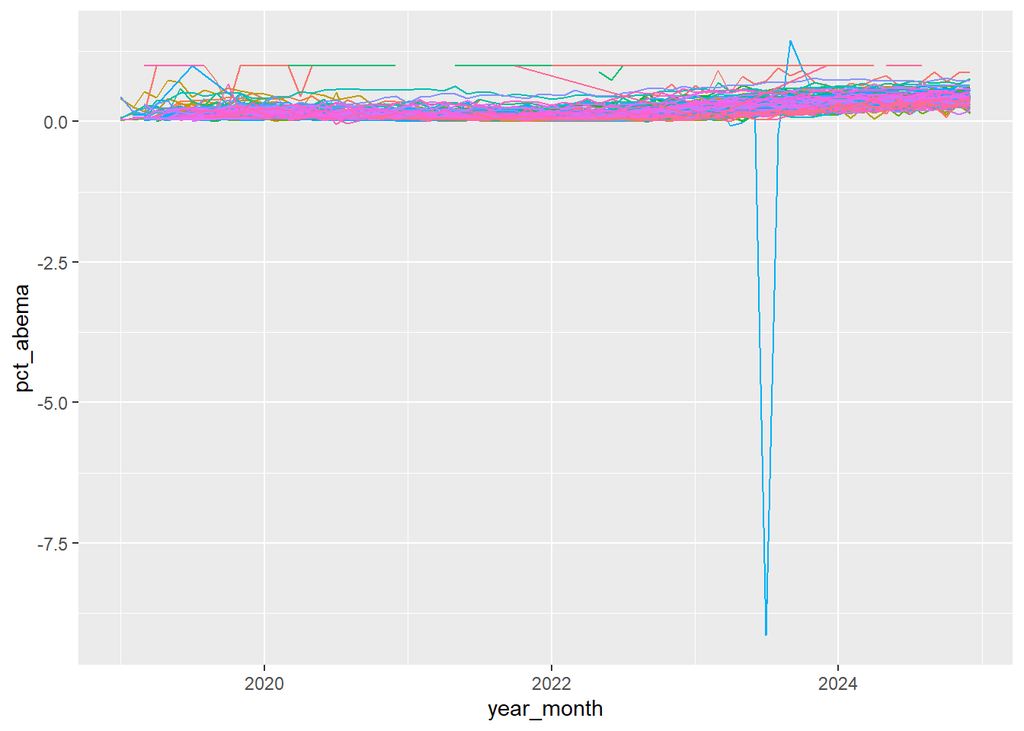

```r
trustData |>
  group_by(year_month) |>
  ggplot(aes(x = year_month, y=pct_abema, colour=new_code)) +
  geom_line() +
  theme(legend.position =  "none")
```

The data is far less interpretable, as different trusts will have different numbers of patients. We need to normalise the data somehow.

## Display Quartiles and Deciles

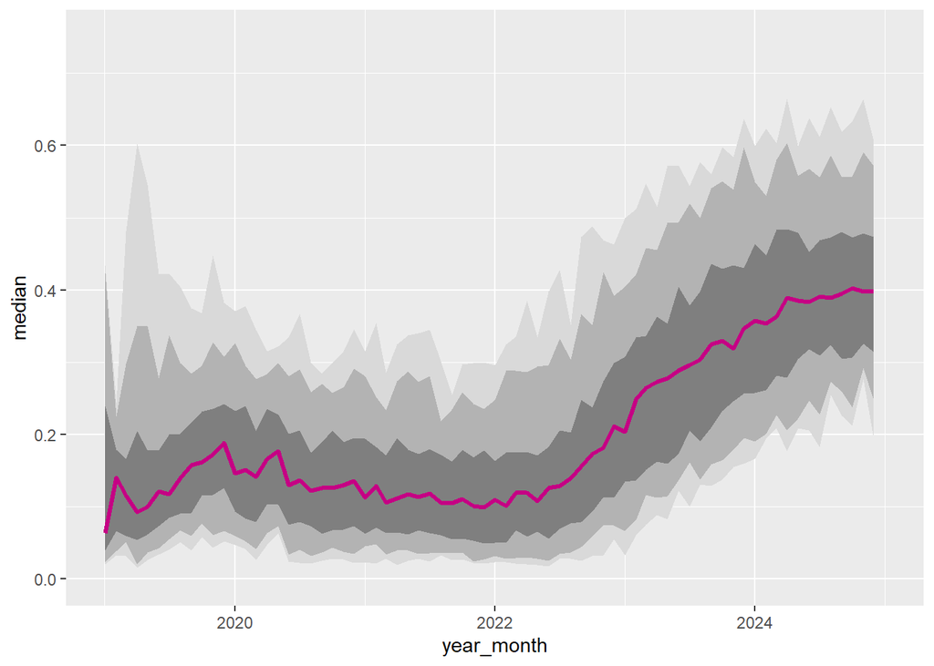

```r
trustData |>
  group_by(year_month) |>
  summarise(median = quantile(pct_abema, probs = 0.5, na.rm=T),
            pct_75 = quantile(pct_abema, probs = 0.75, na.rm=T),
            pct_90 = quantile(pct_abema, probs = 0.9, na.rm=T),
            pct_95 = quantile(pct_abema, probs = 0.95, na.rm=T),
            pct_25 = quantile(pct_abema, probs = 0.25, na.rm=T),
            pct_10 = quantile(pct_abema, probs = 0.1, na.rm=T),
            pct_05 = quantile(pct_abema, probs = 0.05, na.rm=T)
            ) -> abema_quartiles

trustData |>
  ungroup() |>
  ggplot() +
  theme(legend.position =  "none") +
  ylim(0,0.75) +
  xlim(as.Date("2019-01-01"), "2024-12-31") +
  # Layer the quantiles from widest to narrowest
  # add 5-95% quantile
  geom_ribbon(aes(ymin = pct_05, ymax = pct_95, x = year_month ), fill = "grey85", stat="identity", data = abema_quartiles) +
  # add 10-90% quantile
  geom_ribbon(aes(ymin = pct_10, ymax = pct_90, x = year_month ), fill = "grey70", stat="identity", data = abema_quartiles) +
  # add 25-75% quantile
  geom_ribbon(aes(ymin = pct_25, ymax = pct_75, x = year_month ), fill = "grey50", stat="identity", data = abema_quartiles) +
  # add a dotted heavy line for the median
  geom_line(lwd=1.1, colour = BMJ_colours["Abemaciclib"], lty = 1, aes(y=median, x = year_month), data = abema_quartiles) -> quantilePlot

print(quantilePlot)
```

## Format the plot

This plot is starting to look usable, so we will add some improved formatting (titles, axis labels, background panel etc)

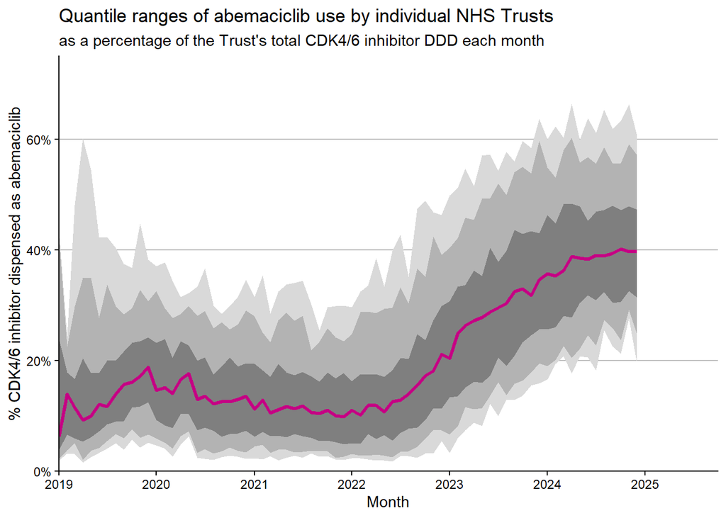

```r
quantilePlot+
  theme_classic() +
  #ggsci::scale_color_jama() +
  scale_color_manual(values=BMJ_colours)+
  theme(panel.grid.major.y = element_line(linewidth = 0.5, colour = "grey")) +
  scale_y_continuous("% CDK4/6 inhibitor dispensed as abemaciclib",
    labels = scales::percent,
    limits = c(0,0.75),
    expand = c(0,0)
  )+
  scale_x_date("Month",
    date_labels = "%Y",
    date_breaks = "1 years",
    limits = as.Date(c("2019-01-01","2025-09-30")),
    expand = c(0,0)
  )+
  ggtitle("Quantile ranges of abemaciclib use by individual NHS Trusts",
          subtitle = "as a percentage of the Trust's total CDK4/6 inhibitor DDD each month") -> quantilePlot
quantilePlot
```

## Annotate the plot

It would be useful to annotate the plot with key timeline events (CDF funding, NICE positive appraisal and 90 day time limit)

We can also label the quantile ranges directly

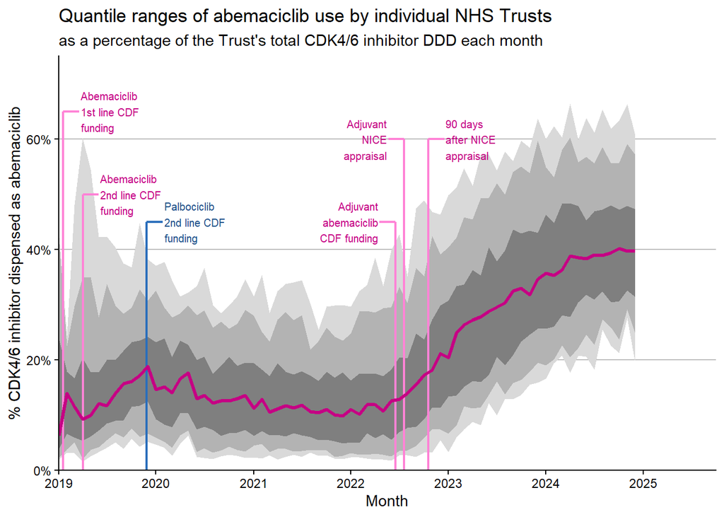

```r
# Build a simple dataset for the annotations

tibble(
  year_month = as.Date(c("2022-06-17", "2022-07-20", "2022-10-18", "2019-11-28", "2019-01-19", "2019-04-02")),
  marker = c(0.45, 0.6, 0.6, 0.45, 0.65, 0.50),
  colour = c("Abemaciclib", "Abemaciclib", "Abemaciclib", "Palbociclib", "Abemaciclib", "Abemaciclib"),
  label = c("Adjuvant abemaciclib CDF funding", "Adjuvant NICE appraisal", "90 days after NICE appraisal",
            "Palbociclib 2nd line CDF funding", "Abemaciclib 1st line CDF funding", "Abemaciclib 2nd line CDF funding"),
  position = c("left", "left", "right", "right", "right", "right")
) -> events

quantilePlot +
  # add vertical markers for annotations
  geom_segment(data=events,
               aes(x=year_month, xend=year_month, y = 0, yend= marker, colour = paste0(colour, "_line")),
               lwd=0.8, lty=1) +
  # plot all the left horizontal marker lines
  geom_segment(data=filter(events, position == "left"),
               aes(x=year_month, xend=year_month-60, y = marker, yend= marker, colour=paste0(colour, "_line")),
               lwd=0.8, lty=1) +
# plot all the right horizontal marker lines
  geom_segment(data=filter(events, position == "right"),
               aes(x=year_month, xend=year_month+60, y = marker, yend= marker, colour=paste0(colour, "_line")),
               lwd=0.8, lty=1) +
# plot all the top horizontal marker lines
  geom_segment(data=filter(events, position == "above"),
               aes(x=year_month-30, xend=year_month+30, y = marker, yend= marker, colour=paste0(colour, "_line")),
               lwd=0.8, lty=1) +
# plot all the left text
  geom_text(data=filter(events, position == "left"),
               aes(x=year_month - 65, y = marker, colour=colour,
                   label = stringr::str_wrap(label, 12)),
            size = 2.7, hjust = 1) +
# plot all the right text
  geom_text(data=filter(events, position == "right"),
               aes(x=year_month + 65, y = marker, colour=colour,
                   label = stringr::str_wrap(label, 12)),
            size = 2.7, hjust = 0) +
# plot all the above text
  geom_text(data=filter(events, position == "above"),
               aes(x=year_month, y = marker+5, colour=colour,
                   label = stringr::str_wrap(label, 12)),
            size = 2.7, hjust = 0.5, vjust = 0) +
  theme(legend.position = "none") +
  # Redraw the media so that it sits over the verticals
  geom_line(lwd=1.1, colour = BMJ_colours["Abemaciclib"], lty = 1, aes(y=median, x = year_month), data = abema_quartiles) -> quantilePlot

print(quantilePlot)
```

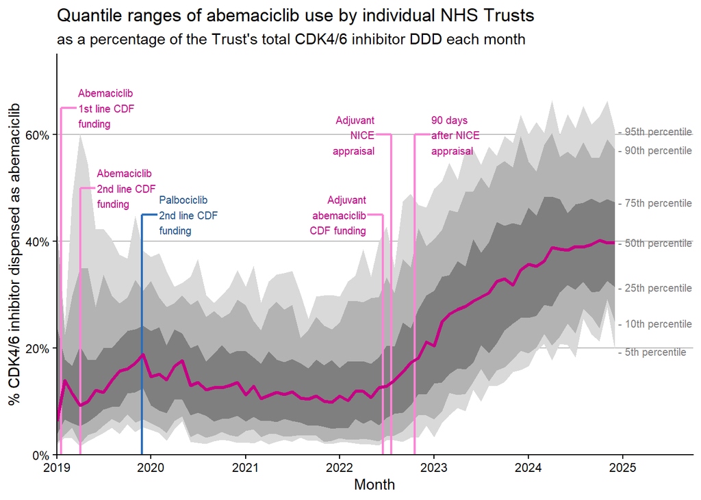

```r
#require(ggbrace)
#require(ggplot2)
require(toOrdinal)
# Label the Quantiles

quantile_labels <-
  tibble(x = as.Date("2024-12-14"),
         y = unlist(c(abema_quartiles[abema_quartiles$year_month==as.Date("2024-12-01"),2:8])),
         label = names(abema_quartiles)[2:8] |> stringr::str_remove_all("pct_")
         ) |>
  rowwise() |>
  mutate(num_label = case_when(
    label == "median" ~ 50,
    T  ~ as.numeric(label)
        )
    ) |>
  mutate(label = toOrdinal(num_label))
quantilePlot +
  #xlim(as.Date("2019-01-01"), "2025-03-30") +
  geom_text( data = quantile_labels,
             aes(x=x,
                 y =  `y`,
                 colour="",
                 label = paste("-",label, "percentile")), inherit.aes = F,
            size = 2.7, hjust = 0, vjust = 0.5)  -> quantilePlot

print(quantilePlot)
```

We can then add some ‘interesting’ trusts to the plot

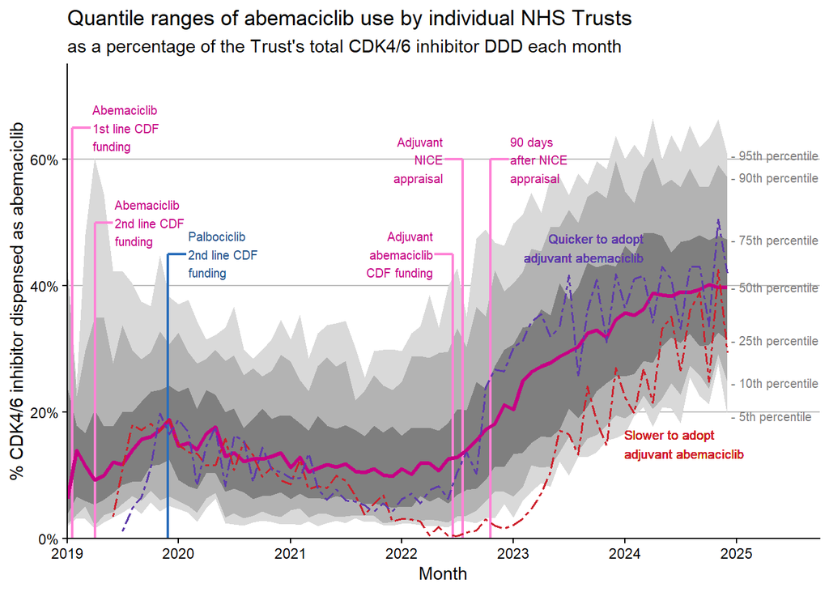

```r
quantilePlot +
  geom_line(data = trustData[trustData$new_code == "RCB",],
            aes(x=year_month, y=pct_abema, colour =  "Low_line"), lwd=0.6, lty=6) +
  geom_text(aes(x=as.Date("2023-12-31"), y=0.15, label = "Slower to adopt\nadjuvant abemaciclib", colour = "Low_line"), size=2.8, hjust=0) +
    geom_line(data = trustData[trustData$new_code == "RXP",],
            aes(x=year_month, y=pct_abema, colour =  "High_line"), lwd=0.6, lty=6) +
  geom_text(aes(x=as.Date("2024-03-01"), y=0.46, label = "Quicker to adopt\nadjuvant abemaciclib", colour = "High_line"), size=2.8, hjust=1) -> quantilePlot

print(quantilePlot)
```

## Export plot for Journal

```r
ggsave(here::here("r/outputs/QuantilePlots_pct_all.svg"), quantilePlot, width = 8, height =6)
ggsave(here::here("r/outputs/QuantilePlots_pct_all.png"), quantilePlot, dpi = 350, width = 8, height =6)
```